# Exploration of Connecticut Vaccination and Voting

John Goldin

2022-05-17 14:57:59 (a work in progress)

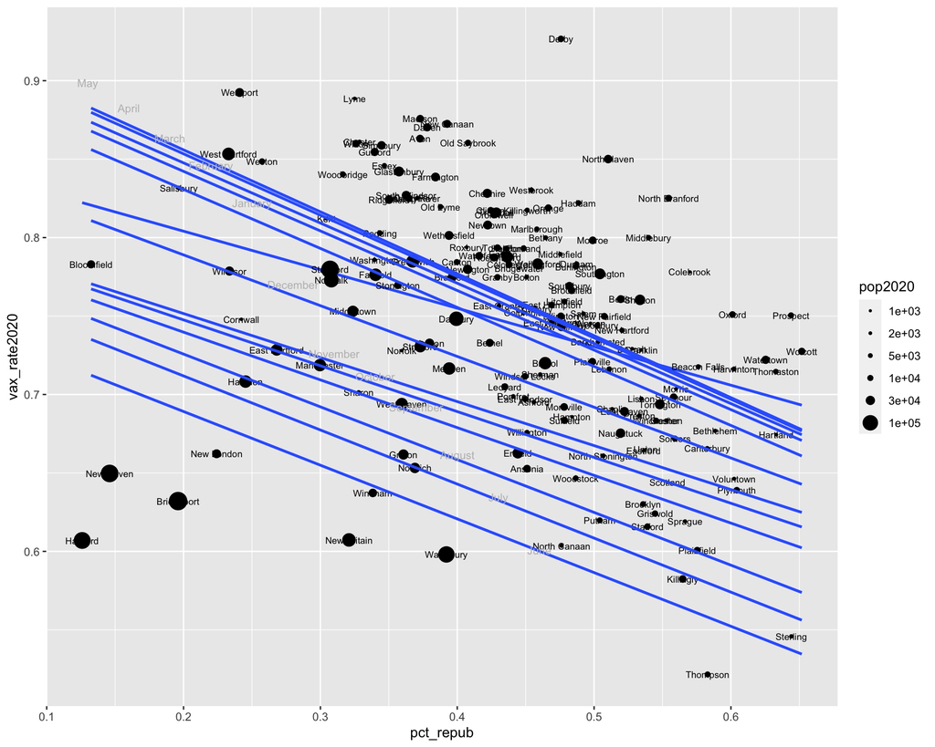

## Connecticut 2020 Presidential Vote and Vaccination by Town

This is a working document as I try to develop a useful way to display vaccination rates by town. Once I get it into a useful state, I plan to publish it on [my blog](https://www.johngoldin.com). In the meantime, I’m going to use this as something like a whiteboard so that I can show my work while I’m still working on it.

The plot below shows the relationship between vaccination rates and percentage of the vote for Trump in the 2020 election.

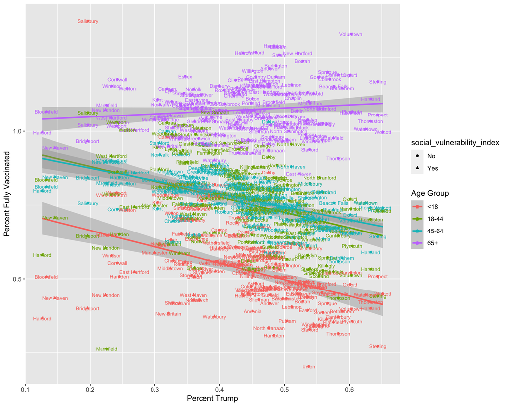

Note that for the trend lines in the plot I have eliminated Mansfield and Simsbury as outliers. Manfield is the location of University of Connecticut. Some students may be counted in census population, but getting their vaccinations elsewhere. I don’t know what’s going on with Simsbury.

The CDC uses someting they call the [social vulnerability index](https://www.atsdr.cdc.gov/placeandhealth/svi/index.html), and DPH has included that as well. DPH flags each town that has at least one census tract that has a social vulnerability index of 75% or greater. Towns showing the social vulnerability index flag tend to have a lower vaccination rate (and a lower Trump percentage), and that’s especially true for the large cities.